# Webscraping no R com rvest

VIII SEMIC - ENCE

Guilherme dos Santos

DME-UFRJ

## Introdução

- Na maioria dos casos, iniciamos a análise de dados a partir de uma tabela. (Planilha do excel, consulta de um banco de dados, etc…)
- Contudo, em alguns casos, nossos dados podem não estar disponíveis diretamente.
- Exemplo:
  - Tabela disponível em algum site sem a opção de download.
  - Corpo de texto de uma página de interesse.

## O que é web scraping?

- Nos cenários citados anteriormente, necessitamos de algumas forma para extrair os dados.
- O conjunto de técnicas para extrair dados da internet ou automatizar procedimentos de estração é chamado de web scraping (ou “raspagem de dados”).

## Então vamos raspar!

[figure not shown]

## Duas abordagens

- Extrair dados do código-fonte de um site
  - Pacote `rvest` em R
- APIs da Web: um conjunto de requisições HTTP estruturadas que retornam dados em JSON ou XML
  - Pacote httr para construir requisições de API
  - Pacotes de API: `weatherData`, `vagalumeR`, `RSpotify`
- Neste minicurso vamos focar na primeira abordagem.

## Mas como fazer isso?

- Precisamos entender algumas coisas
- Como o site funciona.
- Como os dados estão dispostos no site.
- Como podemos extrair as informações que precisamos.
- Como transformar a informação extraída em dados estruturados.

## Sites

- Ao fazer um site há a possibilidade de utilizar algumas linguagens
- Em especial, 3 delas são comuns
  - HTML: descreve a infraestrutura de uma página da web;
  - CSS: define a aparência de um site;
  - JavaScript: determina o comportamento da página.
- HTML e CSS são usados para determinar a estrutura e aparência da página, enquanto javascript é usado para determinar comportamentos de mudança de conteúdo.

## HTML

```html
<!DOCTYPE html>
<html lang="en">
<body>

<h1 href="https://en.wikipedia.org/wiki/Carl_Friedrich_Gauss"> Carl Friedrich Gauss</h1>
<h2> Biography </h2>
<p> Johann Carl Friedrich Gauss was born on 30 April 1777 in Brunswick. </p>
<h2> Profession </h2>
<p> Gauss is considered as one of the greatest mathematician, statistician and physicist of all time. </p>

</body>
</html>
```

## Resultado

# Carl Friedrich Gauss

## Biography

Johann Carl Friedrich Gauss was born on 30 April 1777 in Brunswick.

## Profession

Gauss is considered as one of the greatest mathematician, statistician and physicist of all time.

## Procedimento de extração

- Leitura do código HTML da página.
- Indentificação dos elementos (nós) de interesse.
- Extração desses elementos.
- Transformação para uso e análise no R.

## Setup

- Instalar o pacote rvest

```r
install.packages("rvest")
install.packages("dplyr")
```

- Instalar um seletor de css que vai nos ajudar a encontrar os pontos da página que precisamos na hora de fazer a extração, o [Selector gadget](https://chromewebstore.google.com/detail/selectorgadget/mhjhnkcfbdhnjickkkdbjoemdmbfginb?hl=en&pli=1).

## rvest

- Principais funções
  - `read_html`: Ler o código do site para um objeto no nosso workspace.
  - `html_elements`: Extrair elementos de acordo com uma tag css ou xpath
  - `html_text`: Extrair texto do elemento
  - `html_table`: Extrair tabela do elemento

## Operador pipe (%>%)

- O operador pipe (`|>` no R base ou `%>%` no pacote maggritr) é um operador que pega o elemento anterior e utiliza como o primeiro argumento da próxima função.
- Isto é:

```r
x <- 1:5

x %>% mean()
```

```
[1] 3
```

## Exemplo simples

```r
library(rvest)
# Documento html
html <- minimal_html("
  <ul>
    <li><b>C-3PO</b> is a <i>droid</i> that weighs <span class='weight'>167 kg</span></li>
    <li><b>R2-D2</b> is a <i>droid</i> that weighs <span class='weight'>96 kg</span></li>
    <li><b>Yoda</b> weighs <span class='weight'>66 kg</span></li>
    <li><b>R4-P17</b> is a <i>droid</i></li>
  </ul>
  ")

html %>% html_elements("b") %>% html_text2()
```

```
[1] "C-3PO"  "R2-D2"  "Yoda"   "R4-P17"
```

```r
html %>% html_elements("i") %>% html_text2()
```

```
[1] "droid" "droid" "droid"
```

```r
html %>% html_elements(".weight") %>% html_text2()
```

```
[1] "167 kg" "96 kg"  "66 kg"
```

## Exemplo

- Vamos tentar extrair as informações dos pilotos que venceram corridas na fórmula 1.
- Podemos obter esta informação do [wikipedia](https://pt.wikipedia.org/wiki/Lista_de_vencedores_de_corridas_da_F%C3%B3rmula_1).
- Neste caso, podemos estar interessados em extrair a tabela deste site.

## Extração do wikipedia

```r
url <- "https://pt.wikipedia.org/wiki/Lista_de_vencedores_de_corridas_da_F%C3%B3rmula_1"

site <- read_html(url) # Leitura do site

tabela <- site %>%
  html_elements(".plainrowheaders") %>% # Elementos que quero extrair
  html_table() # Transformando em tabela

head(tabela[[1]])
```

```
# A tibble: 6 × 7
    `#` País      Piloto Vitórias Temporadas `Primeira vitória` `Última vitória`
  <int> <chr>     <chr>     <int> <chr>      <chr>              <chr>
1     1 Reino Un… Lewis…      105 2007–pres… Canadá 2007        Bélgica 2024
2     2 Alemanha  Micha…       91 1991–2006… Bélgica 1992       China 2006
3     3 Países B… Max V…       61 2015–pres… Espanha 2016       Espanha 2024
4     4 Alemanha  Sebas…       53 2007–2022  Itália 2008        Singapura 2019
5     5 França    Alain…       51 1980–1991… França 1981        Alemanha 1993
6     6 Brasil    Ayrto…       41 1984–1994  Portugal 1985      Austrália 1993
```

## Tratamento e análise

```r
library(dplyr)

tabela <- tabela[[1]]

tabela <- janitor::clean_names(tabela)

ranking_paises <- tabela %>%
  group_by(pais) %>% # Agrupando por pais
  summarise(vitorias = sum(vitorias)) %>% # Número de vitórias por pais
  arrange(desc(vitorias)) %>% # Ordenando de forma decrescente
  top_n(10) # Pegando os 10 primeiros
```

## Resultado

```r
knitr::kable(ranking_paises)
```

| pais | vitorias |
| --- | --- |
| Reino Unido | 315 |
| Alemanha | 179 |
| Brasil | 101 |
| França | 81 |
| Países Baixos | 61 |
| Finlândia | 57 |
| Austrália | 45 |
| Itália | 43 |
| Áustria | 41 |
| Argentina | 38 |

## Exemplo de extração

- Vamos tentar extrair as informações do site [boxoffice mojo](https://www.boxofficemojo.com/year/2024/?ref_=bo_lnav_hm_shrt).
- Este é um site que agrega informação sobre bilheteria de filmes.
- Suponha que queremos extrair os filmes que arrecadaram mais em 2024.

## Exemplo de extração

```r
url <- "https://www.boxofficemojo.com/year/2024/?ref_=bo_lnav_hm_shrt"

site <- read_html(url) # Leitura do site

site %>%
  html_elements(".mojo-cell-wide .a-link-normal") %>% # Elementos que quero extrair
  html_text() # Transformando em texto
```

```
  [1] "Inside Out 2"
  [2] "Deadpool & Wolverine"
  [3] "Despicable Me 4"
  [4] "Beetlejuice Beetlejuice"
  [5] "Dune: Part Two"
  [6] "Twisters"
  [7] "Godzilla x Kong: The New Empire"
  [8] "Kung Fu Panda 4"
  [9] "Bad Boys: Ride or Die"
 [10] "Kingdom of the Planet of the Apes"
 [11] "It Ends with Us"
 [12] "A Quiet Place: Day One"
 [13] "The Wild Robot"
 [14] "Ghostbusters: Frozen Empire"
 [15] "IF"
```

[output cut: 185 more lines]

## Exercício rápido

- Extrair a tabela inteira do boxoffice mojo, e não somente os títulos.
- Qual foi a maior bilheteria nesse ano? E foi correspondente a qual filme?

## Incrementando um pouco mais

- Muitas vezes, podemos estar interessados em mais de uma página sobre um mesmo assunto.
- No caso anterior, por exemplo, poderíamos estar interessados em extrair as informações para vários anos diferentes.
- Neste caso, temos que iterar ao longo das URL’s
- Se tivermos sorte, conseguimos fazer isso de um jeito prático.

## Exemplo

- Vamos iterar ao longo dos anos e pegar a tabela de maiores bilheterias

```r
tabelas <- list()

for(i in 1977:2024){
url <- paste0("https://www.boxofficemojo.com/year/", i, "/?ref_=bo_lnav_hm_shrt")

site <- read_html(url) # Leitura do site

tabela_atual <- site %>%
  html_elements("#table") %>%
  html_table()

tabelas <- c(tabelas, tabela_atual)
Sys.sleep(1)
}
# saveRDS(tabelas, file = "tabelas_boxoffice.rds")
```

## Podemos fazer um breve tratamento e análise

```r
library(dplyr)

tabelas <- readRDS("tabelas_boxoffice.rds")

# Adicionando ano
years <- 1977:2024
tabelas <- lapply(seq_along(tabelas), function(i) {
  tabelas[[i]] %>%
    mutate(year = years[i])
})

## Fazendo um tratamento de dados
sucessos <- do.call(rbind, tabelas) ## Juntando todas as tabelas

sucessos <- sucessos %>%
  janitor::clean_names() %>% # limpeza de nomes
  mutate(across(contains("gross"),
                readr::parse_number)) # Transformando receitas em numéricas
```

## Como a maior bilheteria do ano evoluiu ao longo do tempo?

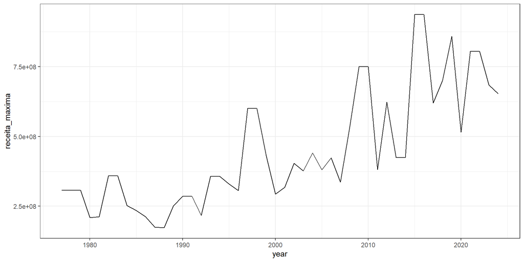

```r
sucessos %>%
  group_by(year) %>%
  summarise(receita_maxima = max(total_gross)) %>%
  ggplot() +
  geom_line(aes(x = year, y = receita_maxima)) +
  theme_bw()
```

## E se quisermos mais informações?

- Um possível cenário que pode acontecer é o seguinte
  - Temos uma lista de possíveis objetos de interesse.
  - Há mais informações necessárias sobre estes objetos.
  - Estas informações estão em páginas próprias para cada objeto.

## Exemplo IMDB

- Suponha que queremos informações do [top 250 Filmes do IMDB](https://www.imdb.com/chart/top/?ref_=nv_mv_250)
- Na página temos informação do título, ano e duração.
- No entanto, não temos informação do elenco, por exemplo.

## Exemplo IMDB

- Podemos usar a função `html_attr` para saber econtrar as urls de cada filme.
- Esta função busca por atributos nomeados no HTML.

```r
url <- "https://www.imdb.com/chart/top/"
site <- read_html(url)

links <- site %>%
  html_elements(".ipc-title-link-wrapper") %>%
  html_attr("href")

links
```

```
 [1] "/title/tt0111161/?ref_=chttp_t_1"  "/title/tt0068646/?ref_=chttp_t_2"
 [3] "/title/tt0468569/?ref_=chttp_t_3"  "/title/tt0071562/?ref_=chttp_t_4"
 [5] "/title/tt0050083/?ref_=chttp_t_5"  "/title/tt0167260/?ref_=chttp_t_6"
 [7] "/title/tt0108052/?ref_=chttp_t_7"  "/title/tt0110912/?ref_=chttp_t_8"
 [9] "/title/tt0120737/?ref_=chttp_t_9"  "/title/tt0060196/?ref_=chttp_t_10"
[11] "/title/tt0109830/?ref_=chttp_t_11" "/title/tt0167261/?ref_=chttp_t_12"
[13] "/title/tt0137523/?ref_=chttp_t_13" "/title/tt1375666/?ref_=chttp_t_14"
[15] "/title/tt0080684/?ref_=chttp_t_15" "/title/tt0133093/?ref_=chttp_t_16"
[17] "/title/tt0099685/?ref_=chttp_t_17" "/title/tt0073486/?ref_=chttp_t_18"
[19] "/title/tt0816692/?ref_=chttp_t_19" "/title/tt0114369/?ref_=chttp_t_20"
[21] "/title/tt0038650/?ref_=chttp_t_21" "/title/tt0047478/?ref_=chttp_t_22"
[23] "/title/tt0102926/?ref_=chttp_t_23" "/title/tt0120815/?ref_=chttp_t_24"
[25] "/title/tt0317248/?ref_=chttp_t_25"
```

## Extração do IMDB

- Vamos extrair primeiro os dados da página geral e depois tentar entrar em cada url para extrair as informações adicionais.

## Extração do IMDB

```r
url <- "https://www.imdb.com/chart/top/"
site <- read_html(url)

titulos <- site %>%
  html_elements(".ipc-title-link-wrapper") %>%
  html_text()

outras <- site %>%
  html_elements(".cli-title-metadata-item") %>%
  html_text2()

outras
```

```
 [1] "1994"   "2h 22m" "16"     "1972"   "2h 55m" "14"     "2008"   "2h 32m"
 [9] "12"     "1974"   "3h 22m" "14"     "1957"   "1h 36m" "Livre"  "2003"
[17] "3h 21m" "14"     "1993"   "3h 15m" "14"     "1994"   "2h 34m" "18"
[25] "2001"   "2h 58m" "12"     "1966"   "2h 41m" "14"     "1994"   "2h 22m"
[33] "14"     "2002"   "2h 59m" "12"     "1999"   "2h 19m" "18"     "2010"
[41] "2h 28m" "14"     "1980"   "2h 4m"  "Livre"  "1999"   "2h 16m" "14"
[49] "1990"   "2h 25m" "14"     "1975"   "2h 13m" "16"     "2014"   "2h 49m"
[57] "10"     "1995"   "2h 7m"  "14"     "1946"   "2h 10m" "Livre"  "1954"
[65] "3h 27m" "10"     "1991"   "1h 58m" "14"     "1998"   "2h 49m" "14"
[73] "2002"   "2h 10m" "18"
```

## Extração IMDB

```r
outras <- matrix(outras, ncol = 3, byrow = TRUE)
colnames(outras) <- c("ano", "duracao", "classificacao")

dados <- cbind.data.frame("titulo" = titulos, outras)
dados <- dados %>% mutate(ano = as.numeric(ano))

head(dados)
```

```
                                   titulo  ano duracao classificacao
1                1. Um Sonho de Liberdade 1994  2h 22m            16
2                    2. O Poderoso Chefão 1972  2h 55m            14
3       3. Batman: O Cavaleiro das Trevas 2008  2h 32m            12
4          4. O Poderoso Chefão: Parte II 1974  3h 22m            14
5             5. 12 Homens e uma Sentença 1957  1h 36m         Livre
6 6. O Senhor dos Anéis: O Retorno do Rei 2003  3h 21m            14
```

## Extração dos atores

```r
for(i in seq_along(links)){
  url <- links[i]
  url_completa <- glue::glue("https://www.imdb.com{url}")

  site <- read_html(url_completa)

  atores <- site %>%
    html_nodes(".sc-cd7dc4b7-1") %>%
    html_text2()

  # personagens <-  site %>%
  #   html_nodes(".title-cast-item__characters-list") %>%
  #   html_text2()

  atores <- paste0(atores, collapse = ",")
  dados$atores[i] <- atores
  Sys.sleep(1)
}

saveRDS(dados, file = "dados_atores.rds")
```

## Quais atores aparecem mais?

```r
dados <- readRDS("dados_atores.rds")

glimpse(dados)
```

```
Rows: 25
Columns: 5
$ titulo        <chr> "1. Um Sonho de Liberdade", "2. O Poderoso Chefão", "3. …
$ ano           <dbl> 1994, 1972, 2008, 1974, 1957, 2003, 1993, 1994, 2001, 19…
$ duracao       <chr> "2h 22m", "2h 55m", "2h 32m", "3h 22m", "1h 36m", "3h 21…
$ classificacao <chr> "16", "14", "12", "14", "Livre", "14", "14", "18", "12",…
$ atores        <chr> "Tim Robbins,Morgan Freeman,Bob Gunton,William Sadler,Cl…
```

```r
strsplit(dados$atores, ",") %>%
  unlist() %>%
  table() %>%
  sort(decreasing = TRUE) %>%
  .[1:20]
```

```
.
     Billy Boyd  Cate Blanchett     Elijah Wood    Ian McKellen   Michael Caine
              3               3               3               3               3
 Morgan Freeman   Orlando Bloom      Sean Astin Viggo Mortensen       Al Pacino
              3               3               3               3               2
   Bernard Hill       Brad Pitt Christopher Lee  Cillian Murphy     David Aston
              2               2               2               2               2
   Diane Keaton    Frank Sivero       John Bach     John Cazale   Marton Csokas
              2               2               2               2               2
```

## Limitações e outros pacotes

- O rvest não consegue lidar com sites que dependem de interação com a pessoa que está navegando. (Em geral, feitos com javascript ou algo do tipo.)
- Na prática, é um pacote válido para lidar com sites mais “estáticos”.
- Para lidar com sites que necessitam de interação com o usuário para revelar conteúdo, existe o pacote [RSelenium](https://cran.r-project.org/web/packages/RSelenium/vignettes/basics.html)
- No python o pacote [Beautiful Soup](https://beautiful-soup-4.readthedocs.io/en/latest/) faz coisas similares ao rvest.

## Agora é com vocês!

- Procure um site do qual você queira extrair informações e tente aplicar o que foi aprendido até aqui!
- Além de realizar a extração, tente fazer algum tipo de análise, mesmo que breve.